# Utility Methods Model

Hampus Broman & William Levén

2021-04

## Looking at the data

We plot the data and can see that there is no obvious large difference between the debt versions.

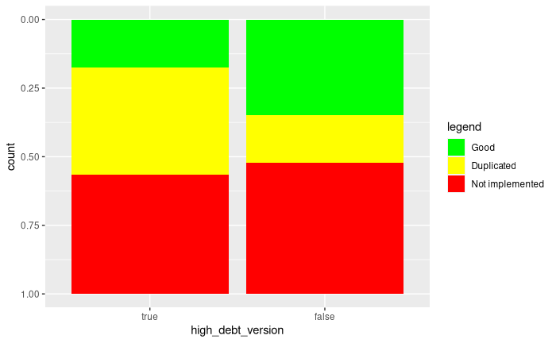

```r
d.both_completed %>%
  ggplot(aes(high_debt_version, fill = hashcode_state)) +
  geom_bar(position = "fill") +
  scale_y_reverse() +
  scale_fill_manual("legend", values = c("Good" = "green", "Duplicated" = "yellow", "Not implemented" = "red"), guide = guide_legend(reverse = TRUE))
```

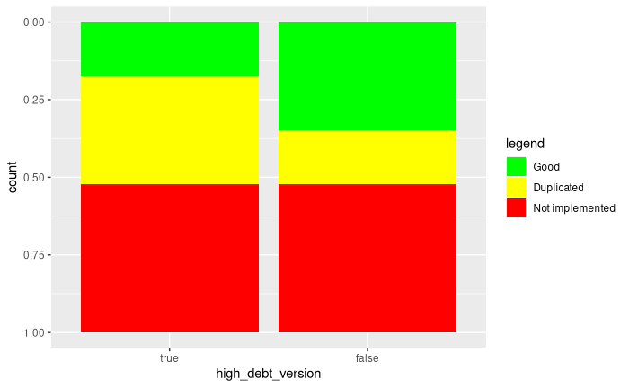

```r
d.both_completed %>%
  ggplot(aes(high_debt_version, fill = equals_state)) +
  geom_bar(position = "fill") +
  scale_y_reverse() +
  scale_fill_manual("legend", values = c("Good" = "green", "Duplicated" = "yellow", "Not implemented" = "red"), guide = guide_legend(reverse = TRUE))
```

## Initial model

We include `high_debt_verison` as well as a varying intercept for each individual in our initial model. Since they may correlate, hashcode and equals state are both included in a single multivariate model.

```r
utility0.with <- extendable_model(
  base_name = "utility0",
  base_formula = "mvbind(hashcode_state, equals_state) ~ 1 + high_debt_version + (1 | c | session)",
  base_priors = c(
    prior(normal(0, 1), class = "b", resp = "equalsstate"),
    prior(normal(0, 1), class = "b", resp = "hashcodestate"),
    prior(normal(0.3, 1), class = "Intercept", resp = "equalsstate"),
    prior(normal(0.3, 1), class = "Intercept", resp = "hashcodestate"),
    prior(exponential(1), class = "sd", resp = "equalsstate"),
    prior(exponential(1), class = "sd", resp = "hashcodestate"),
    prior(lkj(2), class = "L")
  ),
  family = sratio(),
  data = d.both_completed,
)
```

### Selecting Priors

We iterate over the model until we have sane priors

```r
# Default priors:
prior_summary(utility0.with(only_priors= TRUE))
```

```
Setting 'rescor' to FALSE by default for this model
```

```
                prior     class                   coef   group          resp dpar nlpar bound       source
               (flat)         b                                  equalsstate                       default
               (flat)         b high_debt_versionfalse           equalsstate                  (vectorized)
               (flat)         b                                hashcodestate                       default
               (flat)         b high_debt_versionfalse         hashcodestate                  (vectorized)
 student_t(3, 0, 2.5) Intercept                                  equalsstate                       default
 student_t(3, 0, 2.5) Intercept                      1           equalsstate                  (vectorized)
 student_t(3, 0, 2.5) Intercept                      2           equalsstate                  (vectorized)
 student_t(3, 0, 2.5) Intercept                                hashcodestate                       default
 student_t(3, 0, 2.5) Intercept                      1         hashcodestate                  (vectorized)
 student_t(3, 0, 2.5) Intercept                      2         hashcodestate                  (vectorized)
 lkj_corr_cholesky(1)         L                                                                    default
 lkj_corr_cholesky(1)         L                        session                                (vectorized)
 student_t(3, 0, 2.5)        sd                                  equalsstate                       default
 student_t(3, 0, 2.5)        sd                                hashcodestate                       default
 student_t(3, 0, 2.5)        sd                        session   equalsstate                  (vectorized)
 student_t(3, 0, 2.5)        sd              Intercept session   equalsstate                  (vectorized)
 student_t(3, 0, 2.5)        sd                        session hashcodestate                  (vectorized)
 student_t(3, 0, 2.5)        sd              Intercept session hashcodestate                  (vectorized)
```

```r
# Our priors:
prior_summary(utility0.with(sample_prior = "only"))
```

```
Setting 'rescor' to FALSE by default for this model
```

```
                prior     class                   coef   group          resp dpar nlpar bound       source
         normal(0, 1)         b                                  equalsstate                          user
         normal(0, 1)         b high_debt_versionfalse           equalsstate                  (vectorized)
         normal(0, 1)         b                                hashcodestate                          user
         normal(0, 1)         b high_debt_versionfalse         hashcodestate                  (vectorized)
       normal(0.3, 1) Intercept                                  equalsstate                          user
       normal(0.3, 1) Intercept                      1           equalsstate                  (vectorized)
       normal(0.3, 1) Intercept                      2           equalsstate                  (vectorized)
       normal(0.3, 1) Intercept                                hashcodestate                          user
       normal(0.3, 1) Intercept                      1         hashcodestate                  (vectorized)
       normal(0.3, 1) Intercept                      2         hashcodestate                  (vectorized)
 lkj_corr_cholesky(2)         L                                                                       user
 lkj_corr_cholesky(2)         L                        session                                (vectorized)
       exponential(1)        sd                                  equalsstate                          user
       exponential(1)        sd                                hashcodestate                          user
       exponential(1)        sd                        session   equalsstate                  (vectorized)
       exponential(1)        sd              Intercept session   equalsstate                  (vectorized)
       exponential(1)        sd                        session hashcodestate                  (vectorized)
       exponential(1)        sd              Intercept session hashcodestate                  (vectorized)
```

```
Setting 'rescor' to FALSE by default for this model
```

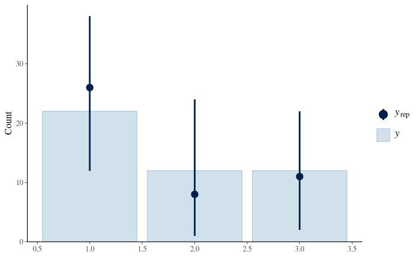

```r
# Prior predictive check
pp_check(utility0.with(sample_prior = "only"), nsamples = 200, type = "bars", resp = "equalsstate")
```

### Model fit

We check the posterior distribution and can see that the model seems to have been able to fit the data well

```
Setting 'rescor' to FALSE by default for this model
```

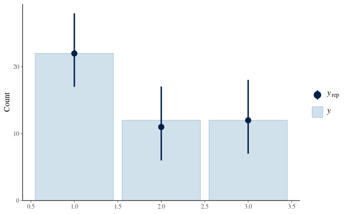

```r
# Posterior predictive check
pp_check(utility0.with(), nsamples = 100, type = "bars", resp = "equalsstate")
```

```
Setting 'rescor' to FALSE by default for this model
```

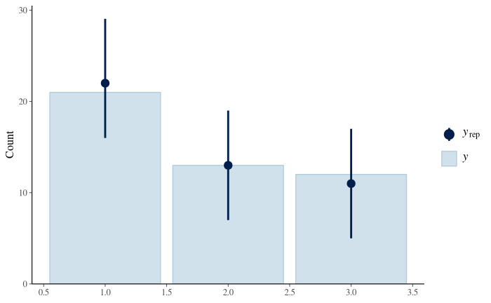

```r
pp_check(utility0.with(), nsamples = 100, type = "bars", resp = "hashcodestate")
```

```r
summary(utility0.with())
```

```
Setting 'rescor' to FALSE by default for this model
```

```
 Family: MV(sratio, sratio)
  Links: mu = logit; disc = identity
         mu = logit; disc = identity
Formula: hashcode_state ~ 1 + high_debt_version + (1 | c | session)
         equals_state ~ 1 + high_debt_version + (1 | c | session)
   Data: as.data.frame(data) (Number of observations: 46)
Samples: 4 chains, each with iter = 2000; warmup = 1000; thin = 1;
         total post-warmup samples = 4000

Group-Level Effects:
~session (Number of levels: 23)
                                                   Estimate Est.Error l-95% CI u-95% CI Rhat Bulk_ESS Tail_ESS
sd(hashcodestate_Intercept)                            1.17      0.52     0.15     2.22 1.00      766      514
sd(equalsstate_Intercept)                              1.27      0.54     0.24     2.40 1.01      823      650
cor(hashcodestate_Intercept,equalsstate_Intercept)     0.72      0.27    -0.12     0.98 1.00      811      673

Population-Level Effects:
                                     Estimate Est.Error l-95% CI u-95% CI Rhat Bulk_ESS Tail_ESS
hashcodestate_Intercept[1]               0.03      0.46    -0.90     0.92 1.00     3580     2716
hashcodestate_Intercept[2]               0.78      0.57    -0.30     1.95 1.00     2446     2967
equalsstate_Intercept[1]                 0.17      0.47    -0.73     1.11 1.00     3742     2770
equalsstate_Intercept[2]                 0.84      0.59    -0.26     2.06 1.00     2229     2580
hashcodestate_high_debt_versionfalse     0.35      0.47    -0.56     1.24 1.00     5295     2729
equalsstate_high_debt_versionfalse       0.45      0.49    -0.52     1.43 1.00     4889     2728

Family Specific Parameters:
                   Estimate Est.Error l-95% CI u-95% CI Rhat Bulk_ESS Tail_ESS
disc_hashcodestate     1.00      0.00     1.00     1.00 1.00     4000     4000
disc_equalsstate       1.00      0.00     1.00     1.00 1.00     4000     4000

Samples were drawn using sample(hmc). For each parameter, Bulk_ESS
and Tail_ESS are effective sample size measures, and Rhat is the potential
scale reduction factor on split chains (at convergence, Rhat = 1).
```

## Model extenstions

We use loo to check some possible extensions on the model.

```r
edlvl_prior <- c(
  prior(dirichlet(2), class = "simo", coef = "moeducation_level1", resp = "equalsstate"),
  prior(dirichlet(2), class = "simo", coef = "moeducation_level1", resp = "hashcodestate")
)

loo(
  utility0.with(),
  utility0.with("work_domain"),
  utility0.with("work_experience_programming.s"),
  utility0.with("work_experience_java.s"),
  utility0.with("education_field"),
  utility0.with("mo(education_level)", edlvl_prior),
  utility0.with("workplace_peer_review"),
  utility0.with("workplace_td_tracking"),
  utility0.with("workplace_pair_programming"),
  utility0.with("workplace_coding_standards"),
  utility0.with("scenario"),
  utility0.with("group"),
  utility0.with("order")
)
```

[output not shown]

```
Output of model 'utility0.with()':

Computed from 4000 by 46 log-likelihood matrix
```

|  | Estimate | SE |
| --- | --- | --- |
| elpd_loo | -103.4 | 7.1 |
| p_loo | 31.5 | 3.8 |
| looic | 206.7 | 14.3 |

```
------
Monte Carlo SE of elpd_loo is NA.

Pareto k diagnostic values:
                         Count Pct.    Min. n_eff
(-Inf, 0.5]   (good)     24    52.2%   383
 (0.5, 0.7]   (ok)       12    26.1%   332
   (0.7, 1]   (bad)       9    19.6%   60
   (1, Inf)   (very bad)  1     2.2%   23
See help('pareto-k-diagnostic') for details.

Output of model 'utility0.with("work_domain")':

Computed from 4000 by 46 log-likelihood matrix
```

|  | Estimate | SE |
| --- | --- | --- |
| elpd_loo | -108.0 | 8.1 |
| p_loo | 36.8 | 4.5 |
| looic | 215.9 | 16.1 |

```
------
Monte Carlo SE of elpd_loo is NA.

Pareto k diagnostic values:
                         Count Pct.    Min. n_eff
(-Inf, 0.5]   (good)     26    56.5%   275
 (0.5, 0.7]   (ok)        9    19.6%   165
   (0.7, 1]   (bad)      11    23.9%   21
   (1, Inf)   (very bad)  0     0.0%   <NA>
See help('pareto-k-diagnostic') for details.

Output of model 'utility0.with("work_experience_programming.s")':

Computed from 4000 by 46 log-likelihood matrix
```

|  | Estimate | SE |
| --- | --- | --- |
| elpd_loo | -104.7 | 7.8 |
| p_loo | 33.4 | 4.1 |
| looic | 209.4 | 15.5 |

```
------
Monte Carlo SE of elpd_loo is NA.

Pareto k diagnostic values:
                         Count Pct.    Min. n_eff
(-Inf, 0.5]   (good)     19    41.3%   481
 (0.5, 0.7]   (ok)       18    39.1%   196
   (0.7, 1]   (bad)       9    19.6%   20
   (1, Inf)   (very bad)  0     0.0%   <NA>
See help('pareto-k-diagnostic') for details.

Output of model 'utility0.with("work_experience_java.s")':

Computed from 4000 by 46 log-likelihood matrix
```

|  | Estimate | SE |
| --- | --- | --- |
| elpd_loo | -103.6 | 7.6 |
| p_loo | 31.7 | 3.8 |
| looic | 207.2 | 15.2 |

```
------
Monte Carlo SE of elpd_loo is NA.

Pareto k diagnostic values:
                         Count Pct.    Min. n_eff
(-Inf, 0.5]   (good)     23    50.0%   612
 (0.5, 0.7]   (ok)       14    30.4%   291
   (0.7, 1]   (bad)       9    19.6%   31
   (1, Inf)   (very bad)  0     0.0%   <NA>
See help('pareto-k-diagnostic') for details.

Output of model 'utility0.with("education_field")':

Computed from 4000 by 46 log-likelihood matrix
```

|  | Estimate | SE |
| --- | --- | --- |
| elpd_loo | -103.8 | 7.2 |
| p_loo | 32.2 | 3.8 |
| looic | 207.7 | 14.5 |

```
------
Monte Carlo SE of elpd_loo is NA.

Pareto k diagnostic values:
                         Count Pct.    Min. n_eff
(-Inf, 0.5]   (good)     19    41.3%   489
 (0.5, 0.7]   (ok)       17    37.0%   164
   (0.7, 1]   (bad)      10    21.7%   42
   (1, Inf)   (very bad)  0     0.0%   <NA>
See help('pareto-k-diagnostic') for details.

Output of model 'utility0.with("mo(education_level)", edlvl_prior)':

Computed from 4000 by 46 log-likelihood matrix
```

|  | Estimate | SE |
| --- | --- | --- |
| elpd_loo | -104.3 | 7.6 |
| p_loo | 33.3 | 4.1 |
| looic | 208.6 | 15.1 |

```
------
Monte Carlo SE of elpd_loo is NA.

Pareto k diagnostic values:
                         Count Pct.    Min. n_eff
(-Inf, 0.5]   (good)     16    34.8%   255
 (0.5, 0.7]   (ok)       24    52.2%   146
   (0.7, 1]   (bad)       5    10.9%   39
   (1, Inf)   (very bad)  1     2.2%   18
See help('pareto-k-diagnostic') for details.

Output of model 'utility0.with("workplace_peer_review")':

Computed from 4000 by 46 log-likelihood matrix
```

|  | Estimate | SE |
| --- | --- | --- |
| elpd_loo | -104.1 | 7.4 |
| p_loo | 33.2 | 4.0 |
| looic | 208.2 | 14.8 |

```
------
Monte Carlo SE of elpd_loo is NA.

Pareto k diagnostic values:
                         Count Pct.    Min. n_eff
(-Inf, 0.5]   (good)     25    54.3%   453
 (0.5, 0.7]   (ok)       13    28.3%   119
   (0.7, 1]   (bad)       8    17.4%   35
   (1, Inf)   (very bad)  0     0.0%   <NA>
See help('pareto-k-diagnostic') for details.

Output of model 'utility0.with("workplace_td_tracking")':

Computed from 4000 by 46 log-likelihood matrix
```

|  | Estimate | SE |
| --- | --- | --- |
| elpd_loo | -103.6 | 7.5 |
| p_loo | 32.9 | 4.0 |
| looic | 207.2 | 15.1 |

```
------
Monte Carlo SE of elpd_loo is NA.

Pareto k diagnostic values:
                         Count Pct.    Min. n_eff
(-Inf, 0.5]   (good)     25    54.3%   456
 (0.5, 0.7]   (ok)       13    28.3%   164
   (0.7, 1]   (bad)       7    15.2%   26
   (1, Inf)   (very bad)  1     2.2%   12
See help('pareto-k-diagnostic') for details.

Output of model 'utility0.with("workplace_pair_programming")':

Computed from 4000 by 46 log-likelihood matrix
```

|  | Estimate | SE |
| --- | --- | --- |
| elpd_loo | -103.3 | 7.2 |
| p_loo | 31.8 | 3.9 |
| looic | 206.6 | 14.5 |

```
------
Monte Carlo SE of elpd_loo is NA.

Pareto k diagnostic values:
                         Count Pct.    Min. n_eff
(-Inf, 0.5]   (good)     25    54.3%   300
 (0.5, 0.7]   (ok)       12    26.1%   187
   (0.7, 1]   (bad)       8    17.4%   23
   (1, Inf)   (very bad)  1     2.2%   112
See help('pareto-k-diagnostic') for details.

Output of model 'utility0.with("workplace_coding_standards")':

Computed from 4000 by 46 log-likelihood matrix
```

|  | Estimate | SE |
| --- | --- | --- |
| elpd_loo | -104.3 | 7.7 |
| p_loo | 32.7 | 4.3 |
| looic | 208.5 | 15.3 |

```
------
Monte Carlo SE of elpd_loo is NA.

Pareto k diagnostic values:
                         Count Pct.    Min. n_eff
(-Inf, 0.5]   (good)     25    54.3%   534
 (0.5, 0.7]   (ok)       14    30.4%   221
   (0.7, 1]   (bad)       5    10.9%   44
   (1, Inf)   (very bad)  2     4.3%   15
See help('pareto-k-diagnostic') for details.

Output of model 'utility0.with("scenario")':

Computed from 4000 by 46 log-likelihood matrix
```

|  | Estimate | SE |
| --- | --- | --- |
| elpd_loo | -103.4 | 7.9 |
| p_loo | 34.0 | 4.2 |
| looic | 206.8 | 15.7 |

```
------
Monte Carlo SE of elpd_loo is NA.

Pareto k diagnostic values:
                         Count Pct.    Min. n_eff
(-Inf, 0.5]   (good)     21    45.7%   450
 (0.5, 0.7]   (ok)       18    39.1%   186
   (0.7, 1]   (bad)       7    15.2%   16
   (1, Inf)   (very bad)  0     0.0%   <NA>
See help('pareto-k-diagnostic') for details.

Output of model 'utility0.with("group")':

Computed from 4000 by 46 log-likelihood matrix
```

|  | Estimate | SE |
| --- | --- | --- |
| elpd_loo | -105.4 | 7.7 |
| p_loo | 34.2 | 4.2 |
| looic | 210.7 | 15.4 |

```
------
Monte Carlo SE of elpd_loo is NA.

Pareto k diagnostic values:
                         Count Pct.    Min. n_eff
(-Inf, 0.5]   (good)     21    45.7%   739
 (0.5, 0.7]   (ok)       16    34.8%   233
   (0.7, 1]   (bad)       8    17.4%   41
   (1, Inf)   (very bad)  1     2.2%   14
See help('pareto-k-diagnostic') for details.

Output of model 'utility0.with("order")':

Computed from 4000 by 46 log-likelihood matrix
```

|  | Estimate | SE |
| --- | --- | --- |
| elpd_loo | -105.5 | 8.6 |
| p_loo | 35.8 | 4.9 |
| looic | 211.0 | 17.1 |

```
------
Monte Carlo SE of elpd_loo is NA.

Pareto k diagnostic values:
                         Count Pct.    Min. n_eff
(-Inf, 0.5]   (good)     21    45.7%   394
 (0.5, 0.7]   (ok)       12    26.1%   135
   (0.7, 1]   (bad)      10    21.7%   34
   (1, Inf)   (very bad)  3     6.5%   17
See help('pareto-k-diagnostic') for details.

Model comparisons:
                                                  elpd_diff se_diff
utility0.with("workplace_pair_programming")        0.0       0.0
utility0.with()                                   -0.1       1.4
utility0.with("scenario")                         -0.1       3.2
utility0.with("workplace_td_tracking")            -0.3       1.5
utility0.with("work_experience_java.s")           -0.3       2.1
utility0.with("education_field")                  -0.5       1.4
utility0.with("workplace_peer_review")            -0.8       1.4
utility0.with("workplace_coding_standards")       -0.9       1.8
utility0.with("mo(education_level)", edlvl_prior) -1.0       1.7
utility0.with("work_experience_programming.s")    -1.4       1.9
utility0.with("group")                            -2.1       1.5
utility0.with("order")                            -2.2       3.1
utility0.with("work_domain")                      -4.7       2.0
```

We pick out some mildly interesting variables and try combining them

```r
loo(
  utility0.with(),
  utility0.with("workplace_pair_programming"),
  utility0.with("scenario"),
  utility0.with("workplace_td_tracking"),


  utility0.with(c("workplace_pair_programming", "scenario")),
  utility0.with(c("workplace_pair_programming", "workplace_td_tracking")),
  utility0.with(c("scenario", "workplace_td_tracking")),
  utility0.with(c("workplace_pair_programming", "scenario", "workplace_td_tracking"))
)
```

[output not shown]

```
Output of model 'utility0.with()':

Computed from 4000 by 46 log-likelihood matrix
```

|  | Estimate | SE |
| --- | --- | --- |
| elpd_loo | -103.4 | 7.1 |
| p_loo | 31.5 | 3.8 |
| looic | 206.7 | 14.3 |

```
------
Monte Carlo SE of elpd_loo is NA.

Pareto k diagnostic values:
                         Count Pct.    Min. n_eff
(-Inf, 0.5]   (good)     24    52.2%   383
 (0.5, 0.7]   (ok)       12    26.1%   332
   (0.7, 1]   (bad)       9    19.6%   60
   (1, Inf)   (very bad)  1     2.2%   23
See help('pareto-k-diagnostic') for details.

Output of model 'utility0.with("workplace_pair_programming")':

Computed from 4000 by 46 log-likelihood matrix
```

|  | Estimate | SE |
| --- | --- | --- |
| elpd_loo | -103.3 | 7.2 |
| p_loo | 31.8 | 3.9 |
| looic | 206.6 | 14.5 |

```
------
Monte Carlo SE of elpd_loo is NA.

Pareto k diagnostic values:
                         Count Pct.    Min. n_eff
(-Inf, 0.5]   (good)     25    54.3%   300
 (0.5, 0.7]   (ok)       12    26.1%   187
   (0.7, 1]   (bad)       8    17.4%   23
   (1, Inf)   (very bad)  1     2.2%   112
See help('pareto-k-diagnostic') for details.

Output of model 'utility0.with("scenario")':

Computed from 4000 by 46 log-likelihood matrix
```

|  | Estimate | SE |
| --- | --- | --- |
| elpd_loo | -103.4 | 7.9 |
| p_loo | 34.0 | 4.2 |
| looic | 206.8 | 15.7 |

```
------
Monte Carlo SE of elpd_loo is NA.

Pareto k diagnostic values:
                         Count Pct.    Min. n_eff
(-Inf, 0.5]   (good)     21    45.7%   450
 (0.5, 0.7]   (ok)       18    39.1%   186
   (0.7, 1]   (bad)       7    15.2%   16
   (1, Inf)   (very bad)  0     0.0%   <NA>
See help('pareto-k-diagnostic') for details.

Output of model 'utility0.with("workplace_td_tracking")':

Computed from 4000 by 46 log-likelihood matrix
```

|  | Estimate | SE |
| --- | --- | --- |
| elpd_loo | -103.6 | 7.5 |
| p_loo | 32.9 | 4.0 |
| looic | 207.2 | 15.1 |

```
------
Monte Carlo SE of elpd_loo is NA.

Pareto k diagnostic values:
                         Count Pct.    Min. n_eff
(-Inf, 0.5]   (good)     25    54.3%   456
 (0.5, 0.7]   (ok)       13    28.3%   164
   (0.7, 1]   (bad)       7    15.2%   26
   (1, Inf)   (very bad)  1     2.2%   12
See help('pareto-k-diagnostic') for details.

Output of model 'utility0.with(c("workplace_pair_programming", "scenario"))':

Computed from 4000 by 46 log-likelihood matrix
```

|  | Estimate | SE |
| --- | --- | --- |
| elpd_loo | -103.9 | 7.7 |
| p_loo | 34.3 | 4.1 |
| looic | 207.9 | 15.4 |

```
------
Monte Carlo SE of elpd_loo is NA.

Pareto k diagnostic values:
                         Count Pct.    Min. n_eff
(-Inf, 0.5]   (good)     20    43.5%   171
 (0.5, 0.7]   (ok)       19    41.3%   120
   (0.7, 1]   (bad)       7    15.2%   32
   (1, Inf)   (very bad)  0     0.0%   <NA>
See help('pareto-k-diagnostic') for details.

Output of model 'utility0.with(c("workplace_pair_programming", "workplace_td_tracking"))':

Computed from 4000 by 46 log-likelihood matrix
```

|  | Estimate | SE |
| --- | --- | --- |
| elpd_loo | -104.2 | 7.6 |
| p_loo | 33.5 | 4.1 |
| looic | 208.5 | 15.1 |

```
------
Monte Carlo SE of elpd_loo is NA.

Pareto k diagnostic values:
                         Count Pct.    Min. n_eff
(-Inf, 0.5]   (good)     22    47.8%   279
 (0.5, 0.7]   (ok)       16    34.8%   223
   (0.7, 1]   (bad)       6    13.0%   55
   (1, Inf)   (very bad)  2     4.3%   25
See help('pareto-k-diagnostic') for details.

Output of model 'utility0.with(c("scenario", "workplace_td_tracking"))':

Computed from 4000 by 46 log-likelihood matrix
```

|  | Estimate | SE |
| --- | --- | --- |
| elpd_loo | -105.0 | 8.2 |
| p_loo | 36.3 | 4.7 |
| looic | 210.0 | 16.5 |

```
------
Monte Carlo SE of elpd_loo is NA.

Pareto k diagnostic values:
                         Count Pct.    Min. n_eff
(-Inf, 0.5]   (good)     23    50.0%   457
 (0.5, 0.7]   (ok)       16    34.8%   155
   (0.7, 1]   (bad)       6    13.0%   47
   (1, Inf)   (very bad)  1     2.2%   13
See help('pareto-k-diagnostic') for details.

Output of model 'utility0.with(c("workplace_pair_programming", "scenario", "workplace_td_tracking"))':

Computed from 4000 by 46 log-likelihood matrix
```

|  | Estimate | SE |
| --- | --- | --- |
| elpd_loo | -104.5 | 8.1 |
| p_loo | 35.9 | 4.4 |
| looic | 208.9 | 16.2 |

```
------
Monte Carlo SE of elpd_loo is NA.

Pareto k diagnostic values:
                         Count Pct.    Min. n_eff
(-Inf, 0.5]   (good)     20    43.5%   580
 (0.5, 0.7]   (ok)       17    37.0%   143
   (0.7, 1]   (bad)       8    17.4%   32
   (1, Inf)   (very bad)  1     2.2%   30
See help('pareto-k-diagnostic') for details.

Model comparisons:
                                                                                    elpd_diff se_diff
utility0.with("workplace_pair_programming")                                          0.0       0.0
utility0.with()                                                                     -0.1       1.4
utility0.with("scenario")                                                           -0.1       3.2
utility0.with("workplace_td_tracking")                                              -0.3       1.5
utility0.with(c("workplace_pair_programming", "scenario"))                          -0.6       2.7
utility0.with(c("workplace_pair_programming", "workplace_td_tracking"))             -0.9       0.6
utility0.with(c("workplace_pair_programming", "scenario", "workplace_td_tracking")) -1.2       2.9
utility0.with(c("scenario", "workplace_td_tracking"))                               -1.7       3.3
```

## Candidate models

We inspect some of our top performing models.

All models seems to have sampled nicely (rhat is ca 1 and fluffy plots) they also have about the same fit to the data and similar estimates for the high_debt_version beta parameters

```r
utility0 <- utility0.with()
```

```
Setting 'rescor' to FALSE by default for this model
```

```r
summary(utility0)
```

```
 Family: MV(sratio, sratio)
  Links: mu = logit; disc = identity
         mu = logit; disc = identity
Formula: hashcode_state ~ 1 + high_debt_version + (1 | c | session)
         equals_state ~ 1 + high_debt_version + (1 | c | session)
   Data: as.data.frame(data) (Number of observations: 46)
Samples: 4 chains, each with iter = 2000; warmup = 1000; thin = 1;
         total post-warmup samples = 4000

Group-Level Effects:
~session (Number of levels: 23)
                                                   Estimate Est.Error l-95% CI u-95% CI Rhat Bulk_ESS Tail_ESS
sd(hashcodestate_Intercept)                            1.17      0.52     0.15     2.22 1.00      766      514
sd(equalsstate_Intercept)                              1.27      0.54     0.24     2.40 1.01      823      650
cor(hashcodestate_Intercept,equalsstate_Intercept)     0.72      0.27    -0.12     0.98 1.00      811      673

Population-Level Effects:
                                     Estimate Est.Error l-95% CI u-95% CI Rhat Bulk_ESS Tail_ESS
hashcodestate_Intercept[1]               0.03      0.46    -0.90     0.92 1.00     3580     2716
hashcodestate_Intercept[2]               0.78      0.57    -0.30     1.95 1.00     2446     2967
equalsstate_Intercept[1]                 0.17      0.47    -0.73     1.11 1.00     3742     2770
equalsstate_Intercept[2]                 0.84      0.59    -0.26     2.06 1.00     2229     2580
hashcodestate_high_debt_versionfalse     0.35      0.47    -0.56     1.24 1.00     5295     2729
equalsstate_high_debt_versionfalse       0.45      0.49    -0.52     1.43 1.00     4889     2728

Family Specific Parameters:
                   Estimate Est.Error l-95% CI u-95% CI Rhat Bulk_ESS Tail_ESS
disc_hashcodestate     1.00      0.00     1.00     1.00 1.00     4000     4000
disc_equalsstate       1.00      0.00     1.00     1.00 1.00     4000     4000

Samples were drawn using sample(hmc). For each parameter, Bulk_ESS
and Tail_ESS are effective sample size measures, and Rhat is the potential
scale reduction factor on split chains (at convergence, Rhat = 1).
```

```r
ranef(utility0)
```

```
$session
, , hashcodestate_Intercept

                           Estimate Est.Error        Q2.5     Q97.5
6033d69a5af2c702367b3a95  0.5770224 0.8197972 -0.90825647 2.3648980
6033d90a5af2c702367b3a96  0.4882677 0.7995734 -0.90247572 2.2233500
6034fc165af2c702367b3a98  0.5740172 0.8345621 -0.97746100 2.3939100
603500725af2c702367b3a99  0.1927449 0.7226336 -1.23274300 1.7212763
603f97625af2c702367b3a9d -0.3197127 0.8020335 -2.05031375 1.2092785
603fd5d95af2c702367b3a9e -1.2724986 1.1363902 -3.90370300 0.4215610
60409b7b5af2c702367b3a9f -0.3937646 0.7834185 -2.09704125 1.0552665
604b82b5a7718fbed181b336 -1.2994400 1.1702459 -4.04819250 0.4224808
6050c1bf856f36729d2e5218  0.1669187 0.7156507 -1.23963625 1.6864690
6050e1e7856f36729d2e5219  0.4920684 0.7914028 -0.93203273 2.2522310
6055fdc6856f36729d2e521b -1.2748411 1.1429953 -3.87022100 0.4627689
60589862856f36729d2e521f -0.3261563 0.8237365 -2.11289450 1.2434620
605a30a7856f36729d2e5221 -1.2839468 1.1451587 -3.90579050 0.4079941
605afa3a856f36729d2e5222  0.9127781 0.8402656 -0.44074022 2.8148333
605c8bc6856f36729d2e5223  0.9151462 0.8498751 -0.50343563 2.8429143
605f3f2d856f36729d2e5224  0.9062380 0.8118369 -0.41752455 2.6851325
605f46c3856f36729d2e5225 -1.2914342 1.1781116 -4.12825875 0.4395585
60605337856f36729d2e5226  1.8529236 1.2053667 -0.01560261 4.6200000
60609ae6856f36729d2e5228  0.9089262 0.8339908 -0.46832095 2.7515065
6061ce91856f36729d2e522e  0.4903094 0.8348899 -0.97799107 2.3451633
6061f106856f36729d2e5231 -0.6259384 0.8436804 -2.38794500 0.8928197
6068ea9f856f36729d2e523e  0.9231497 0.8640958 -0.47992590 2.9276225
6075ab05856f36729d2e5247 -1.2785506 1.1767868 -4.07743425 0.4363284

, , equalsstate_Intercept

                           Estimate Est.Error         Q2.5     Q97.5
6033d69a5af2c702367b3a95  0.6131962 0.8723242 -0.968217925 2.5167523
6033d90a5af2c702367b3a96  0.5443795 0.8574978 -0.942229275 2.4617373
6034fc165af2c702367b3a98  0.6160210 0.8727570 -0.975173575 2.5584365
603500725af2c702367b3a99  0.2120113 0.7685071 -1.257000000 1.8209523
603f97625af2c702367b3a9d -0.3370443 0.8553172 -2.175712000 1.2790978
603fd5d95af2c702367b3a9e -1.3627865 1.2020791 -4.203757750 0.5610844
60409b7b5af2c702367b3a9f -0.4087077 0.8305166 -2.223553500 1.1618043
604b82b5a7718fbed181b336 -1.3970125 1.2381031 -4.336635000 0.4860435
6050c1bf856f36729d2e5218  0.1983196 0.7481282 -1.250824750 1.7765863
6050e1e7856f36729d2e5219  0.5226101 0.8601904 -0.970350950 2.4412558
6055fdc6856f36729d2e521b -1.3731611 1.2073792 -4.128866500 0.4862522
60589862856f36729d2e521f -0.3445698 0.8468244 -2.102360500 1.2651790
605a30a7856f36729d2e5221 -1.3856320 1.1864909 -4.084270000 0.4193415
605afa3a856f36729d2e5222  0.9953643 0.9006571 -0.517394375 2.9710473
605c8bc6856f36729d2e5223  0.9816449 0.8787539 -0.481929700 2.9337243
605f3f2d856f36729d2e5224  0.9725911 0.8845918 -0.491856250 2.9278213
605f46c3856f36729d2e5225 -1.3800473 1.2172878 -4.267463000 0.4725200
60605337856f36729d2e5226  2.0114708 1.2987367 -0.004681547 4.9978103
60609ae6856f36729d2e5228  1.0069461 0.8955696 -0.467951550 2.9797243
6061ce91856f36729d2e522e  0.5238682 0.8786997 -1.067893250 2.4719580
6061f106856f36729d2e5231 -0.9593174 1.0256166 -3.384478000 0.6960141
6068ea9f856f36729d2e523e  0.9855661 0.8783190 -0.484391625 2.8498202
6075ab05856f36729d2e5247 -1.3510610 1.2208644 -4.238188000 0.5074760
```

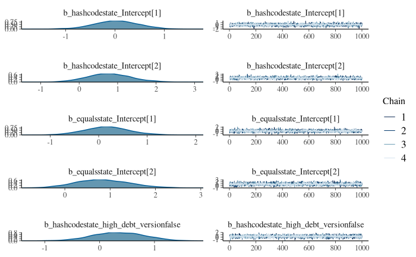

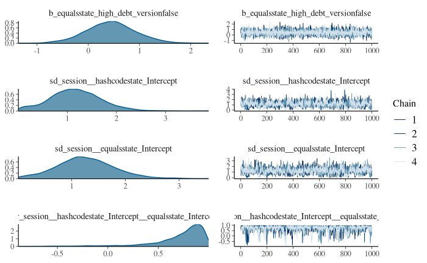

```r
plot(utility0, ask = FALSE)
```

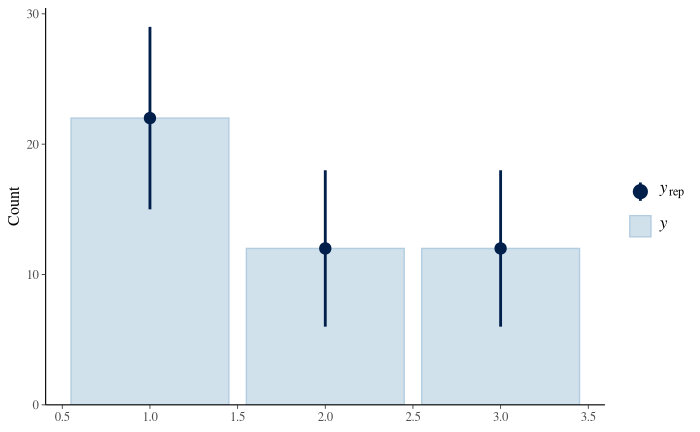

```r
pp_check(utility0, nsamples = 200, type = "bars", resp = "equalsstate")
```

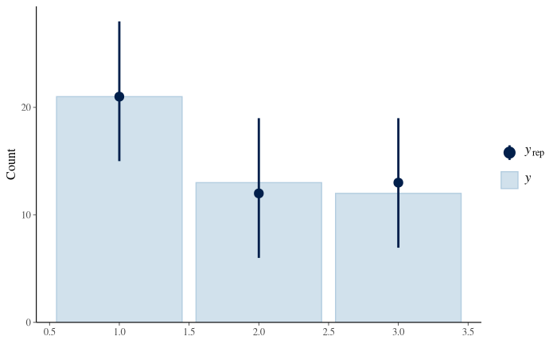

```r
pp_check(utility0, nsamples = 200, type = "bars", resp = "hashcodestate")
```

```r
utility1 <- utility0.with("workplace_pair_programming")
```

```
Setting 'rescor' to FALSE by default for this model
```

```r
summary(utility1)
```

```
 Family: MV(sratio, sratio)
  Links: mu = logit; disc = identity
         mu = logit; disc = identity
Formula: hashcode_state ~ 1 + high_debt_version + (1 | c | session) + workplace_pair_programming
         equals_state ~ 1 + high_debt_version + (1 | c | session) + workplace_pair_programming
   Data: as.data.frame(data) (Number of observations: 46)
Samples: 4 chains, each with iter = 2000; warmup = 1000; thin = 1;
         total post-warmup samples = 4000

Group-Level Effects:
~session (Number of levels: 23)
                                                   Estimate Est.Error l-95% CI u-95% CI Rhat Bulk_ESS Tail_ESS
sd(hashcodestate_Intercept)                            1.17      0.51     0.23     2.25 1.00     1061      800
sd(equalsstate_Intercept)                              1.26      0.51     0.30     2.35 1.00     1196      978
cor(hashcodestate_Intercept,equalsstate_Intercept)     0.73      0.24     0.07     0.97 1.00     1532      991

Population-Level Effects:
                                              Estimate Est.Error l-95% CI u-95% CI Rhat Bulk_ESS Tail_ESS
hashcodestate_Intercept[1]                        0.48      0.70    -0.91     1.88 1.00     4670     2944
hashcodestate_Intercept[2]                        1.27      0.78    -0.20     2.90 1.00     4101     2816
equalsstate_Intercept[1]                          0.60      0.70    -0.74     2.01 1.00     4252     3157
equalsstate_Intercept[2]                          1.29      0.80    -0.17     2.97 1.00     3706     3055
hashcodestate_high_debt_versionfalse              0.37      0.48    -0.53     1.32 1.00     7274     3092
hashcodestate_workplace_pair_programmingfalse     0.61      0.67    -0.73     1.93 1.00     4687     2851
equalsstate_high_debt_versionfalse                0.47      0.49    -0.49     1.44 1.00     8059     2789
equalsstate_workplace_pair_programmingfalse       0.55      0.67    -0.81     1.88 1.00     4557     2923

Family Specific Parameters:
                   Estimate Est.Error l-95% CI u-95% CI Rhat Bulk_ESS Tail_ESS
disc_hashcodestate     1.00      0.00     1.00     1.00 1.00     4000     4000
disc_equalsstate       1.00      0.00     1.00     1.00 1.00     4000     4000

Samples were drawn using sample(hmc). For each parameter, Bulk_ESS
and Tail_ESS are effective sample size measures, and Rhat is the potential
scale reduction factor on split chains (at convergence, Rhat = 1).
```

```r
ranef(utility1)
```

```
$session
, , hashcodestate_Intercept

                            Estimate Est.Error        Q2.5     Q97.5
6033d69a5af2c702367b3a95  0.49203670 0.8161236 -0.96897065 2.2803978
6033d90a5af2c702367b3a96  0.42678676 0.8465284 -1.13211250 2.2669570
6034fc165af2c702367b3a98  0.49168557 0.8159902 -0.94479585 2.3106578
603500725af2c702367b3a99  0.08933557 0.7217257 -1.32994900 1.5976720
603f97625af2c702367b3a9d -0.42095335 0.8139025 -2.15779300 1.1129645
603fd5d95af2c702367b3a9e -1.12736873 1.1338201 -3.73424025 0.6780307
60409b7b5af2c702367b3a9f -0.48380477 0.7907641 -2.16978950 1.0140898
604b82b5a7718fbed181b336 -1.14662946 1.1361028 -3.84677300 0.5727482
6050c1bf856f36729d2e5218  0.08054339 0.7335215 -1.31061650 1.6583733
6050e1e7856f36729d2e5219  0.74202012 0.8946041 -0.81817635 2.7888555
6055fdc6856f36729d2e521b -1.13701995 1.1840779 -3.93043750 0.6763880
60589862856f36729d2e521f -0.41469034 0.7979716 -2.15724650 1.0695178
605a30a7856f36729d2e5221 -1.33790864 1.1329993 -3.99817675 0.3303945
605afa3a856f36729d2e5222  0.83021266 0.8332529 -0.56868248 2.6706715
605c8bc6856f36729d2e5223  0.84599255 0.8494304 -0.56737293 2.8160055
605f3f2d856f36729d2e5224  0.84267142 0.8371725 -0.60039770 2.6443060
605f46c3856f36729d2e5225 -1.12816263 1.1629355 -3.92499175 0.6450148
60605337856f36729d2e5226  2.11975509 1.2941469  0.03110518 4.9936552
60609ae6856f36729d2e5228  0.84067367 0.8249350 -0.54447718 2.6671850
6061ce91856f36729d2e522e  0.40349260 0.8068725 -1.10036050 2.1325160
6061f106856f36729d2e5231 -0.71948966 0.8720458 -2.59470500 0.8450102
6068ea9f856f36729d2e523e  0.83632398 0.8335701 -0.59090650 2.6585315
6075ab05856f36729d2e5247 -1.33163620 1.1268977 -4.07531550 0.3453298

, , equalsstate_Intercept

                           Estimate Est.Error       Q2.5     Q97.5
6033d69a5af2c702367b3a95  0.5501508 0.8634656 -1.0162565 2.4063270
6033d90a5af2c702367b3a96  0.4742443 0.8846310 -1.1141935 2.3411298
6034fc165af2c702367b3a98  0.5517253 0.8717773 -0.9988927 2.5327375
603500725af2c702367b3a99  0.1190597 0.7544121 -1.3918013 1.6612705
603f97625af2c702367b3a9d -0.4163439 0.8548531 -2.2031295 1.2597935
603fd5d95af2c702367b3a9e -1.1875980 1.1634520 -3.9073638 0.6545588
60409b7b5af2c702367b3a9f -0.4994592 0.8421798 -2.2837108 1.0701438
604b82b5a7718fbed181b336 -1.2270667 1.1941390 -4.0583418 0.6442373
6050c1bf856f36729d2e5218  0.1152738 0.7945871 -1.4114667 1.7750883
6050e1e7856f36729d2e5219  0.7959662 0.9244052 -0.8275784 2.7716910
6055fdc6856f36729d2e521b -1.2078669 1.2068273 -4.1451607 0.7064327
60589862856f36729d2e521f -0.4087286 0.8804370 -2.3148150 1.2610075
605a30a7856f36729d2e5221 -1.4017370 1.1728547 -4.1734860 0.3942303
605afa3a856f36729d2e5222  0.8930163 0.8706242 -0.5685813 2.7996325
605c8bc6856f36729d2e5223  0.9188040 0.8796043 -0.5583916 2.9068957
605f3f2d856f36729d2e5224  0.9000266 0.8666983 -0.5819065 2.8079840
605f46c3856f36729d2e5225 -1.1818651 1.1963106 -3.9960668 0.6726996
60605337856f36729d2e5226  2.2515058 1.3054356  0.0569931 5.1706025
60609ae6856f36729d2e5228  0.8995622 0.8979324 -0.6229972 2.9099475
6061ce91856f36729d2e522e  0.4597793 0.8452922 -1.0986358 2.2408883
6061f106856f36729d2e5231 -1.0376887 1.0746658 -3.5453555 0.6722397
6068ea9f856f36729d2e523e  0.9105408 0.8733563 -0.5529522 2.8079583
6075ab05856f36729d2e5247 -1.4228746 1.1884685 -4.1409243 0.3816934
```

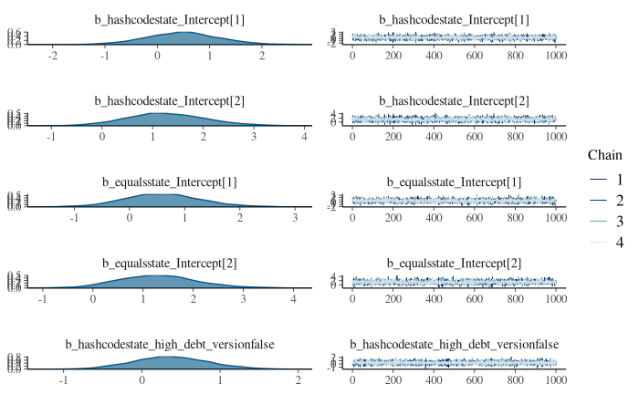

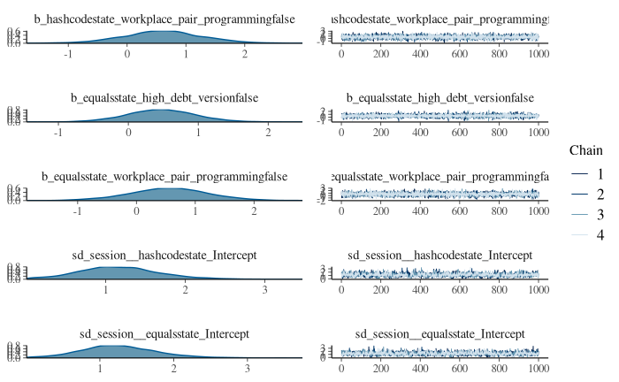

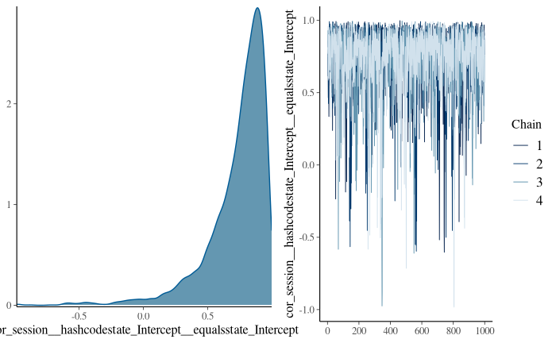

```r
plot(utility1, ask = FALSE)
```

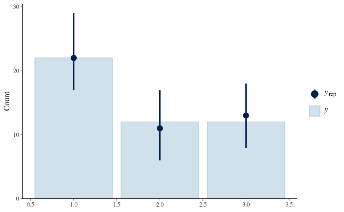

```r
pp_check(utility1, nsamples = 200, type = "bars", resp = "equalsstate")
```

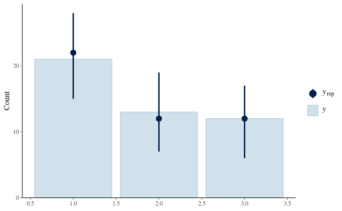

```r
pp_check(utility1, nsamples = 200, type = "bars", resp = "hashcodestate")
```

```r
utility2 <- utility0.with("scenario")
```

```
Setting 'rescor' to FALSE by default for this model
```

```r
summary(utility2)
```

```
 Family: MV(sratio, sratio)
  Links: mu = logit; disc = identity
         mu = logit; disc = identity
Formula: hashcode_state ~ 1 + high_debt_version + (1 | c | session) + scenario
         equals_state ~ 1 + high_debt_version + (1 | c | session) + scenario
   Data: as.data.frame(data) (Number of observations: 46)
Samples: 4 chains, each with iter = 2000; warmup = 1000; thin = 1;
         total post-warmup samples = 4000

Group-Level Effects:
~session (Number of levels: 23)
                                                   Estimate Est.Error l-95% CI u-95% CI Rhat Bulk_ESS Tail_ESS
sd(hashcodestate_Intercept)                            1.29      0.52     0.36     2.43 1.00     1355     1279
sd(equalsstate_Intercept)                              1.38      0.55     0.38     2.55 1.00     1241     1198
cor(hashcodestate_Intercept,equalsstate_Intercept)     0.76      0.21     0.18     0.98 1.00     1634     1487

Population-Level Effects:
                                     Estimate Est.Error l-95% CI u-95% CI Rhat Bulk_ESS Tail_ESS
hashcodestate_Intercept[1]               0.29      0.52    -0.73     1.32 1.00     5844     3237
hashcodestate_Intercept[2]               1.16      0.66    -0.07     2.56 1.00     4043     3211
equalsstate_Intercept[1]                 0.40      0.51    -0.57     1.45 1.00     6002     3454
equalsstate_Intercept[2]                 1.15      0.68    -0.11     2.56 1.00     4143     2132
hashcodestate_high_debt_versionfalse     0.34      0.49    -0.62     1.30 1.00     8795     3000
hashcodestate_scenariotickets            0.58      0.50    -0.37     1.60 1.00     8142     2878
equalsstate_high_debt_versionfalse       0.44      0.48    -0.46     1.42 1.00     7934     3003
equalsstate_scenariotickets              0.49      0.51    -0.52     1.48 1.00     8325     2681

Family Specific Parameters:
                   Estimate Est.Error l-95% CI u-95% CI Rhat Bulk_ESS Tail_ESS
disc_hashcodestate     1.00      0.00     1.00     1.00 1.00     4000     4000
disc_equalsstate       1.00      0.00     1.00     1.00 1.00     4000     4000

Samples were drawn using sample(hmc). For each parameter, Bulk_ESS
and Tail_ESS are effective sample size measures, and Rhat is the potential
scale reduction factor on split chains (at convergence, Rhat = 1).
```

```r
ranef(utility2)
```

```
$session
, , hashcodestate_Intercept

                           Estimate Est.Error        Q2.5     Q97.5
6033d69a5af2c702367b3a95  0.5587641 0.8560300 -0.98868203 2.4116958
6033d90a5af2c702367b3a96  0.4988000 0.8429445 -1.03011425 2.3418303
6034fc165af2c702367b3a98  0.6897239 0.8883424 -0.88665535 2.5961907
603500725af2c702367b3a99  0.1933122 0.7739103 -1.36070625 1.7884613
603f97625af2c702367b3a9d -0.3261205 0.8526498 -2.12529450 1.2597308
603fd5d95af2c702367b3a9e -1.4607106 1.2403132 -4.40430425 0.3875300
60409b7b5af2c702367b3a9f -0.4800479 0.8432027 -2.28726075 1.1058008
604b82b5a7718fbed181b336 -1.4865809 1.2470226 -4.39369200 0.4296416
6050c1bf856f36729d2e5218  0.1983125 0.7346219 -1.26108125 1.7378645
6050e1e7856f36729d2e5219  0.4865385 0.8369035 -1.09121500 2.3196120
6055fdc6856f36729d2e521b -1.4584555 1.2163326 -4.21415275 0.3842873
60589862856f36729d2e521f -0.4219109 0.8349995 -2.20019150 1.1658215
605a30a7856f36729d2e5221 -1.4836453 1.2328081 -4.30285575 0.3831840
605afa3a856f36729d2e5222  1.0213708 0.8527468 -0.38787037 2.8917030
605c8bc6856f36729d2e5223  1.0340809 0.9116135 -0.45374237 3.0673025
605f3f2d856f36729d2e5224  1.0132710 0.8895080 -0.50113000 2.9849020
605f46c3856f36729d2e5225 -1.4562755 1.1905485 -4.31939125 0.3606719
60605337856f36729d2e5226  2.0533844 1.2524210  0.03919322 4.8789942
60609ae6856f36729d2e5228  1.0318245 0.8796621 -0.40305315 3.0274925
6061ce91856f36729d2e522e  0.4827942 0.8076903 -1.01360200 2.2233992
6061f106856f36729d2e5231 -0.7679307 0.9092857 -2.84325900 0.8236862
6068ea9f856f36729d2e523e  1.0389203 0.8827079 -0.47603622 3.0324763
6075ab05856f36729d2e5247 -1.4671166 1.2552332 -4.43775100 0.4224124

, , equalsstate_Intercept

                           Estimate Est.Error        Q2.5     Q97.5
6033d69a5af2c702367b3a95  0.6220494 0.9037328 -1.05166425 2.5984303
6033d90a5af2c702367b3a96  0.5463460 0.8818674 -1.05694450 2.4631913
6034fc165af2c702367b3a98  0.7435218 0.9242533 -0.90805368 2.7593900
603500725af2c702367b3a99  0.2243337 0.7932214 -1.31257725 1.8500912
603f97625af2c702367b3a9d -0.3359264 0.8972397 -2.26879800 1.3874355
603fd5d95af2c702367b3a9e -1.5470110 1.2611090 -4.46909625 0.3780216
60409b7b5af2c702367b3a9f -0.5016704 0.8745608 -2.40507250 1.1356093
604b82b5a7718fbed181b336 -1.5499040 1.2874080 -4.52428000 0.4391055
6050c1bf856f36729d2e5218  0.2245465 0.7919207 -1.33459075 1.8846703
6050e1e7856f36729d2e5219  0.5345314 0.9019865 -1.05264900 2.4813430
6055fdc6856f36729d2e521b -1.5168792 1.2412472 -4.35139800 0.4790012
60589862856f36729d2e521f -0.4372522 0.8750896 -2.35053850 1.2131213
605a30a7856f36729d2e5221 -1.5729045 1.3060531 -4.56940225 0.4020933
605afa3a856f36729d2e5222  1.0752850 0.9112553 -0.49326962 3.0973248
605c8bc6856f36729d2e5223  1.1103548 0.9098103 -0.40332377 3.0700373
605f3f2d856f36729d2e5224  1.0866504 0.9096687 -0.47003917 3.0543818
605f46c3856f36729d2e5225 -1.5465321 1.2701167 -4.43766075 0.4109540
60605337856f36729d2e5226  2.2030731 1.3517871  0.08785462 5.3937208
60609ae6856f36729d2e5228  1.0980932 0.9210148 -0.46511502 3.1428152
6061ce91856f36729d2e522e  0.5263381 0.8724240 -1.11979625 2.4106253
6061f106856f36729d2e5231 -1.0909426 1.1344215 -3.65744300 0.7447540
6068ea9f856f36729d2e523e  1.1025963 0.9218532 -0.48088978 3.0543755
6075ab05856f36729d2e5247 -1.5540166 1.2944977 -4.49702850 0.4336825
```

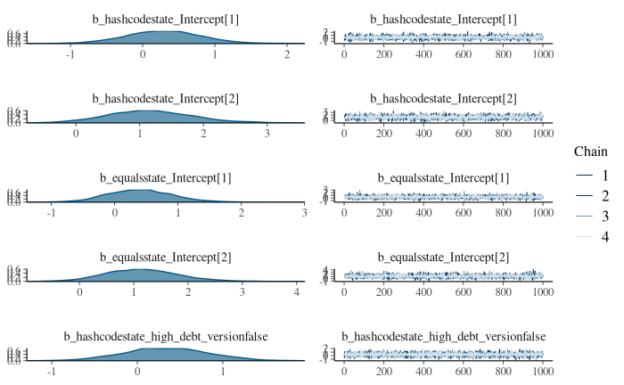

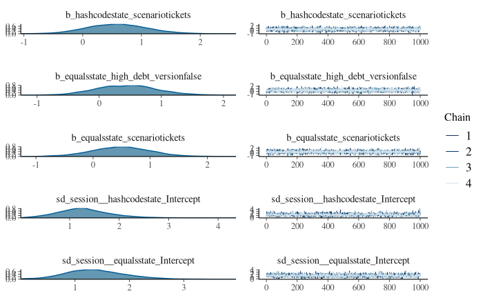

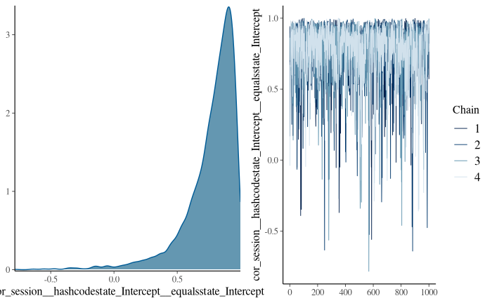

```r
plot(utility2, ask = FALSE)
```

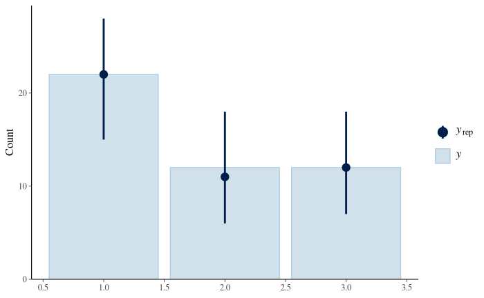

```r
pp_check(utility2, nsamples = 200, type = "bars", resp = "equalsstate")
```

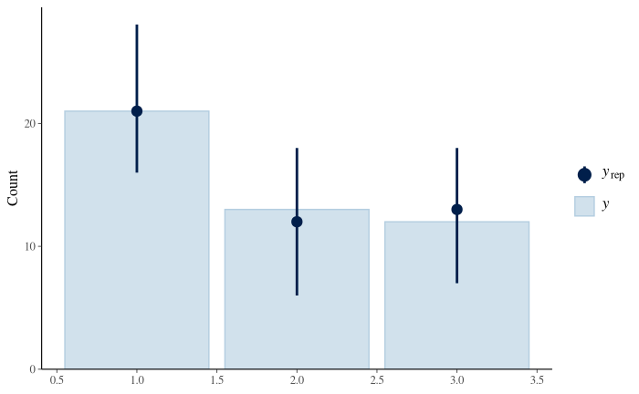

```r
pp_check(utility2, nsamples = 200, type = "bars", resp = "hashcodestate")
```

### Final model

All models have sampled well and have similar predictions. We will proceed with the simplest model utility0.

### Model with with incomplete data points

Some participants did only complete one scenario. Those has been excluded from the initial dataset to improve sampling of the models. We do however want to use all data we can and will therefore try to fit the model with the complete dataset.

```r
utility0.all <- brm(
  mvbind(hashcode_state, equals_state) ~ 1 + high_debt_version + (1 | c | session),
  prior = c(
    prior(normal(0, 1), class = "b", resp = "equalsstate"),
    prior(normal(0, 1), class = "b", resp = "hashcodestate"),
    prior(normal(0.3, 1), class = "Intercept", resp = "equalsstate"),
    prior(normal(0.3, 1), class = "Intercept", resp = "hashcodestate"),
    prior(exponential(1), class = "sd", resp = "equalsstate"),
    prior(exponential(1), class = "sd", resp = "hashcodestate"),
    prior(lkj(2), class = "L")
  ),
  family = sratio(),
  data = as.data.frame(d.completed),
  file = "fits/utility0.all",
  file_refit = "on_change"
)
```

```
Setting 'rescor' to FALSE by default for this model
```

[output not shown]

[output cut: 149 more lines]

[output not shown]

[output not shown]

[output cut: 43 more lines]

[output not shown]

```r
summary(utility0.all)
```

```
 Family: MV(sratio, sratio)
  Links: mu = logit; disc = identity
         mu = logit; disc = identity
Formula: hashcode_state ~ 1 + high_debt_version + (1 | c | session)
         equals_state ~ 1 + high_debt_version + (1 | c | session)
   Data: as.data.frame(d.completed) (Number of observations: 52)
Samples: 4 chains, each with iter = 2000; warmup = 1000; thin = 1;
         total post-warmup samples = 4000

Group-Level Effects:
~session (Number of levels: 29)
                                                   Estimate Est.Error l-95% CI u-95% CI Rhat Bulk_ESS Tail_ESS
sd(hashcodestate_Intercept)                            1.31      0.49     0.43     2.34 1.00     1259      933
sd(equalsstate_Intercept)                              1.39      0.53     0.43     2.53 1.00     1225     1207
cor(hashcodestate_Intercept,equalsstate_Intercept)     0.80      0.18     0.31     0.98 1.00     1336     1000

Population-Level Effects:
                                     Estimate Est.Error l-95% CI u-95% CI Rhat Bulk_ESS Tail_ESS
hashcodestate_Intercept[1]               0.08      0.44    -0.80     0.96 1.00     5096     3287
hashcodestate_Intercept[2]               0.98      0.57    -0.10     2.14 1.00     2804     3091
equalsstate_Intercept[1]                 0.22      0.45    -0.67     1.11 1.00     4919     3547
equalsstate_Intercept[2]                 1.04      0.58    -0.03     2.25 1.00     2708     2894
hashcodestate_high_debt_versionfalse     0.19      0.48    -0.74     1.12 1.00     9345     2536
equalsstate_high_debt_versionfalse       0.28      0.48    -0.65     1.24 1.00     8852     2675

Family Specific Parameters:
                   Estimate Est.Error l-95% CI u-95% CI Rhat Bulk_ESS Tail_ESS
disc_hashcodestate     1.00      0.00     1.00     1.00 1.00     4000     4000
disc_equalsstate       1.00      0.00     1.00     1.00 1.00     4000     4000

Samples were drawn using sample(hmc). For each parameter, Bulk_ESS
and Tail_ESS are effective sample size measures, and Rhat is the potential
scale reduction factor on split chains (at convergence, Rhat = 1).
```

```r
ranef(utility0.all)
```

```
$session
, , hashcodestate_Intercept

                           Estimate Est.Error       Q2.5     Q97.5
6033c6fc5af2c702367b3a93  0.3180951 0.8974541 -1.4467815 2.1909070
6033d69a5af2c702367b3a95  0.7335313 0.8511919 -0.8073164 2.5857868
6033d90a5af2c702367b3a96  0.6861156 0.8559927 -0.8387651 2.4831965
6034fc165af2c702367b3a98  0.7280869 0.8587652 -0.7746964 2.5455145
603500725af2c702367b3a99  0.3215564 0.7556450 -1.1588938 1.8688458
603f84f15af2c702367b3a9b -1.0081610 1.2011263 -3.7020722 1.0393120
603f97625af2c702367b3a9d -0.3067226 0.8225116 -2.0613358 1.2425605
603fd5d95af2c702367b3a9e -1.4111164 1.1758349 -4.1483047 0.4686452
60409b7b5af2c702367b3a9f -0.3326487 0.8235849 -2.0427895 1.2154980
604b82b5a7718fbed181b336 -1.4155596 1.1868985 -4.1521782 0.4953115
604f1239a7718fbed181b33f  0.2963335 0.9334970 -1.5512810 2.2305660
6050c1bf856f36729d2e5218  0.3310761 0.7582065 -1.0936510 1.8918400
6050e1e7856f36729d2e5219  0.6711583 0.8619325 -0.8744572 2.5855210
6055fdc6856f36729d2e521b -1.3728093 1.1461543 -4.0792820 0.4707949
60579f2a856f36729d2e521e -1.0119689 1.2097818 -3.8330210 0.9804220
60589862856f36729d2e521f -0.3016141 0.8650164 -2.0902410 1.3857403
605a30a7856f36729d2e5221 -1.4294814 1.2190935 -4.3085770 0.4343648
605afa3a856f36729d2e5222  1.1532983 0.8677507 -0.3447333 2.9724193
605c8bc6856f36729d2e5223  1.1418719 0.8597235 -0.3129756 3.0890823
605f3f2d856f36729d2e5224  1.1451230 0.8687963 -0.3790290 2.9913150
605f46c3856f36729d2e5225 -1.4197589 1.1815452 -4.0715152 0.4549698
60605337856f36729d2e5226  2.1896722 1.2411035  0.1498635 5.0098518
60609ae6856f36729d2e5228  1.1574751 0.8920637 -0.3186512 3.1554128
6061ce91856f36729d2e522e  0.6836380 0.8385436 -0.8260160 2.5276065
6061f106856f36729d2e5231 -0.6732762 0.9142601 -2.6673447 0.9802759
60672faa856f36729d2e523c -1.0087809 1.1902786 -3.8437867 0.9354649
6068ea9f856f36729d2e523e  1.1451508 0.8467389 -0.2910432 3.0575535
606db69d856f36729d2e5243 -1.0017204 1.2350999 -3.8563267 1.0732470
6075ab05856f36729d2e5247 -1.4026966 1.1790153 -4.1793265 0.4757663

, , equalsstate_Intercept

                           Estimate Est.Error       Q2.5     Q97.5
6033c6fc5af2c702367b3a93  0.3589481 0.9482452 -1.4535603 2.3816385
6033d69a5af2c702367b3a95  0.7656038 0.8991800 -0.8869589 2.6149088
6033d90a5af2c702367b3a96  0.7368615 0.9113814 -0.8941408 2.7556020
```

[output cut: 11 more lines]

```
60579f2a856f36729d2e521e -1.0755495 1.2936089 -3.9663575 1.1631088
60589862856f36729d2e521f -0.2997811 0.8799342 -2.0623930 1.3771043
605a30a7856f36729d2e5221 -1.5052293 1.2564055 -4.5917462 0.4207491
605afa3a856f36729d2e5222  1.2257815 0.9082049 -0.3676768 3.2060333
605c8bc6856f36729d2e5223  1.2211527 0.9056273 -0.3042481 3.2521293
605f3f2d856f36729d2e5224  1.2228366 0.9222512 -0.3000032 3.2210063
605f46c3856f36729d2e5225 -1.4937952 1.2420742 -4.2790440 0.4904516
60605337856f36729d2e5226  2.3261801 1.3223131  0.2309414 5.3997080
60609ae6856f36729d2e5228  1.2251803 0.9201225 -0.3173138 3.2298335
6061ce91856f36729d2e522e  0.7267459 0.9007515 -0.9053370 2.6798673
6061f106856f36729d2e5231 -0.9640160 1.0781577 -3.4251572 0.7778599
60672faa856f36729d2e523c -1.0690318 1.2603640 -3.9294990 1.0442763
6068ea9f856f36729d2e523e  1.2105553 0.9160973 -0.3464901 3.2241245
606db69d856f36729d2e5243 -1.0808322 1.3367068 -4.1729935 1.1312658
6075ab05856f36729d2e5247 -1.5112817 1.2634003 -4.5955620 0.4864290
```

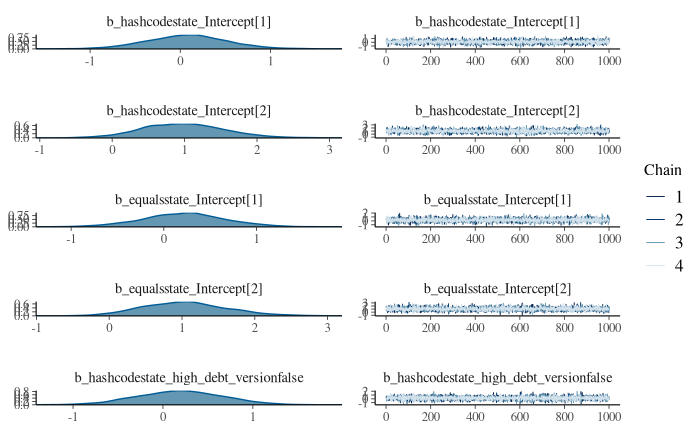

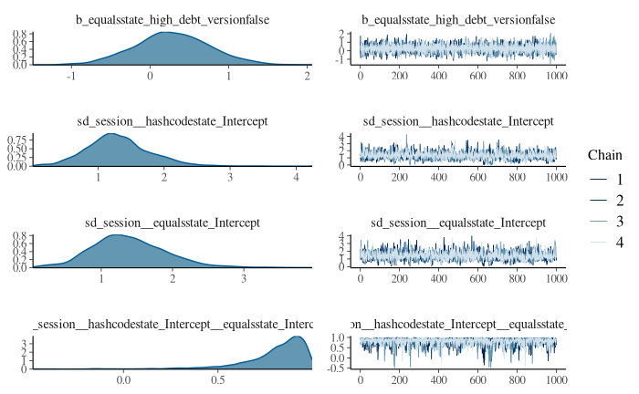

```r
plot(utility0.all, ask = FALSE)
```

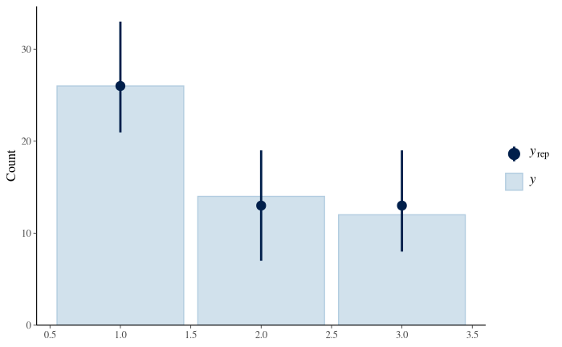

```r
pp_check(utility0.all, nsamples = 200, type = "bars", resp = "equalsstate")
```

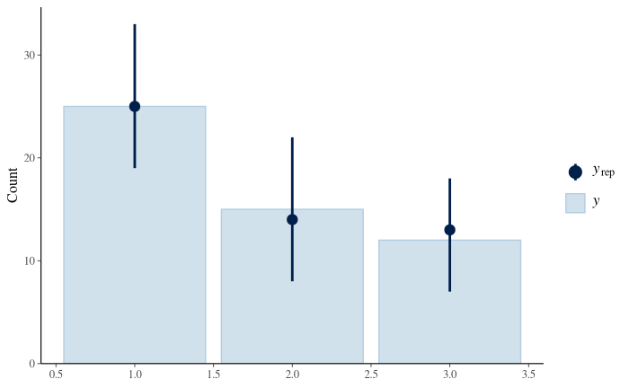

```r
pp_check(utility0.all, nsamples = 200, type = "bars", resp = "hashcodestate")
```

Training the model on all data points only slightly increases the uncertanty and did not result in any sampling problems. We will proceed with the model fitted to all the data.

## Interpreting the model

Extract posterior samples:

```r
post <- posterior_predict(utility0.all, newdata = data.frame(
  high_debt_version = c("false", "true"),
  session = NA
))

post_hashcode <- post[,,"hashcodestate"]
post_hashcode.low <-  post_hashcode[,1]
post_hashcode.high <- post_hashcode[,2]
summary(post_hashcode)
```

```
       V1              V2
 Min.   :1.000   Min.   :1.000
 1st Qu.:1.000   1st Qu.:1.000
 Median :2.000   Median :1.000
 Mean   :1.761   Mean   :1.679
 3rd Qu.:2.000   3rd Qu.:2.000
 Max.   :3.000   Max.   :3.000
```

```r
post_equals <- post[,,"equalsstate"]
post_equals.low <-  post_equals[,1]
post_equals.high <- post_equals[,2]
summary(post_equals)
```

```
       V1              V2
 Min.   :1.000   Min.   :1.000
 1st Qu.:1.000   1st Qu.:1.000
 Median :2.000   Median :1.000
 Mean   :1.782   Mean   :1.664
 3rd Qu.:3.000   3rd Qu.:2.000
 Max.   :3.000   Max.   :3.000
```